# ESTADÍSTICA APLICADA A CONFIABILIDAD CON PYTHON

## Aplicación de la estadística descriptica en la ingeniería de confiabilidad.

### Ejercicio práctico de aplicación de la estadística descriptica en la ingeniería de confiabilidad por medio del uso de Python y sus librerias.

**Objetivo:** El objetivo del presente artículo es realizar un ejercicio práctico el uso de la estadística descriptica en la ingeniería de confiabilidad, apoyado en el uso de Python para su ejecución.

**Alcance:** El alcance del presente documento no es un manual teórico de estadística, aunque tendrá la suficiente teoría como para refrescar y afianzar los conocimientos del área; tampoco se trata de un manual para aprender a programar en Python y el manejo de las librerías asociadas al ejercicio, pero veremos algunas partes de código que el lector deberá profundizar individualmente para hacer uso de las herramientas aquí planteadas.

El alcance del documento trata de resolver los problemas de literatura encontrada en la actualidad, mezclando la teoría y la practica a través de una herramienta computacional Open Source. ¿Porque en Python? – en primer lugar, porque es open source y está al alcance de todos. En segundo lugar porque es el lenguaje de programación más utilizado por la comunidad científica mundial que le permitirá al lector cuestionarse sobre la necesidad del aprendizaje y los posibilidades del uso de esta herramienta no solamente para realizar análisis probabilísticos sino también para adentrarse en el mundo de la inteligencia artificial y sus subespecialidades como el aprendizaje de máquinas o el aprendizaje profundo sin salir de la misma aplicación y sobretodo sin ningún costo directo, más que el de utilizar el tiempo libre para adquirí nuevos conocimientos. Esto último podría significar mucho o demasiado precio para algunas personas, pero vale la pena acotar la frase de Eric Hoffer:

*En tiempos de cambio, quienes estén abiertos al aprendizaje se adueñarán del futuro, mientras que aquellos que creen saberlo todo estarán bien equipados para un mundo que ya no existe.*

Las herramientas comerciales son muy buenas en lo que hacen y resuelven con facilidad los problemas de ingeniería pero la mayoría son muy especializadas en una sola rama y no cubren el espectro de posibilidades que tiene Python, su uso está muy limitado a empresas o privados que puedan pagar las licencias necesarias lo que limita la diseminación del conocimiento y sesga el aprendizaje de los profesionales en formación; por lo anterior, uno de los principales objetivos del presente documento es acercar estas herramientas al uso cotidiano en la ingeniería y de los profesionales ávidos de conocimiento.

## La estadística descriptiva en la ingeniería de confiabilidad

**1. Estadística Descriptiva** La Estadística Descriptiva se ocupa fundamentalmente del estudio de la variación o dispersión, y para ello se apoya en herramientas matemáticas conocidas como “Distribuciones de Probabilidad” que permiten organizar, describir, representar matemática y gráficamente la información sobre variables y cuantificar su incertidumbre. Las variables objeto de estudio de la Estadística Descriptiva, se conoce como Variable Random, Aleatorias o Distribuidas.

**1.1 Variable Random, Aleatoria o Distribuida** Se denomina variable random, aleatoria o distribuida, a una variable “X” que por sus características pueda tomar un conjunto de valores (x1, x2, x3, x4,... xn-1,) cada uno de los cuales tiene una probabilidad de ocurrencia (p1, p2, p3, p4,... pn-1,), sin que se pueda asegurar específicamente cuál de todos estos probables valores tomará la variable. Las variables aleatorias pueden ser continuas o discretas.

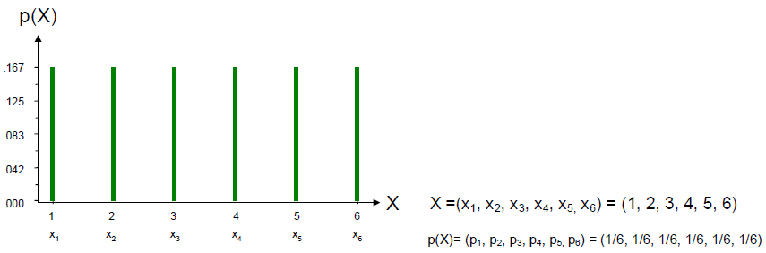

Las variables random se dividen en **“variables continuas” y “variables discretas”**. Si una variable random sólo puede tomar valores enteros, es decir, un número finito o infinito de valores “numerables o contables” diremos que es discreta. Si teóricamente, puede tomar todos los valores de un intervalo dado, diremos que es continua.

Para el mejor entendimiento de estos conceptos, analicemos los siguientes ejemplos: Realizamos un experimento que consiste en lanzar dos dados. El espacio de resultados de la variable aleatoria “suma de los puntos aparecidos en cada dado” este compuesto por un número limitado de probables resultados (2,3,4,5,6,7,8,9,10,11,12), y no debemos esperar que tome valores como 7.5, 9.8 o 2.2. Por esta razón, esta variable se clasifica como variable random discreta.

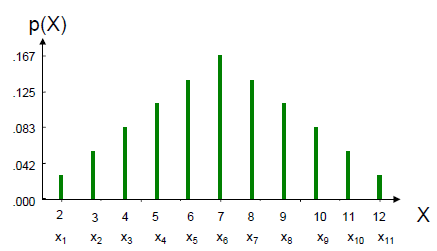

Consideremos ahora el experimento que consiste en elegir al azar 500 personas y medir su estatura. El espectro de probables resultados es infinito, y aunque podríamos definir un rango (entre 0.25m y 3.5m) la variable puede tomar cualquier valor en ese rango. Por esta razón, esta variable se clasifica como variable random continua.

Cuando existe duda acerca de la naturaleza discreta o continua de una variable aleatoria podemos usar la siguiente regla del dedo gordo: si los diferentes valores de la variable aleatoria los obtenemos a través de un proceso de medición (medición de peso, volumen, longitud, tiempo, etc.) la variable es continua. Por otra parte, si los diferentes valores de la variable aleatoria se obtienen a través de un proceso de conteo (número de vehículos, número de pozos secos, eventos por unidad de tiempo, etc.) la variable es discreta. *Fundamentalmente, se identifican las variables aleatorias discretas porque para cuantificar su frecuencia hay que “contar”; mientras que para las variables aleatorias continuas hay que “medir”.*

**1.2 Distribuciones de Probabilidad** Las Distribuciones de Probabilidad son modelos que describen la forma en que se espera que varíen los resultados o probables valores de una variable aleatoria. Debido a que estas distribuciones tratan sobre expectativas de que algo suceda, resultan ser modelos muy útiles para hacer inferencias y para tomar decisiones en condiciones de incertidumbre. Las Distribuciones de Probabilidad, son esencialmente modelos matemáticos que pueden representarse gráficamente, que relacionan los diversos probables valores que puede tomar una variable random, con la frecuencia de ocurrencia de cada uno de estos probables valores.

Tradicionalmente se clasifica a las distribuciones de probabilidad en dos grandes familias: **Distribuciones Paramétricas y Distribuciones No Paramétricas**. Las Distribuciones No Paramétricas *son esencialmente modelos gráficos que representan un grupo particular de observaciones de una variable random y que relacionan los diversos valores de la variable que se analiza, con su probabilidad de ocurrencia*. Las Distribuciones No Paramétricas son el objeto de estudio de un campo especial de la Estadística conocido como “Estadística No Paramétrica”. En este texto, de este extenso campo de la Estadística No Paramétrica solo revisaremos el caso de los conocidos Histogramas de Frecuencia o Distribuciones Empíricas.

En algunos casos, *a estos modelos gráficos se les puede asociar una función matemática que relaciona los diversos probables valores que puede tomar una variable random, con la probabilidad de ocurrencia de cada uno de estos probables valores. Este tipo de distribuciones es conocido como Distribuciones Paramétricas*. Como paso previo a la determinación de una distribución de probabilidad que representa a una variable random, suelen construirse modelos gráficos, que no tienen una función matemática asociada.

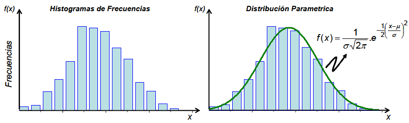

Estos modelos permiten ordenar la información sobre una variable en estudio, obtenida de un experimento aleatorio o de un registro de observaciones. Estos modelos gráficos se conocen con el nombre de Distribuciones Empíricas o Histogramas de Frecuencias.

Para facilitar el aprendizaje de la teoría aquí planteada realizaremos un ejercicio con datos reales de parámetros que caracterizan los yacimientos de crudo. Esta data se utilizará a lo largo de las diferentes etapas de desarrollo de los ejercicios prácticos.

*Ejercicio 1 - Distribuciones de Probabilidad*

Para mostrar la aplicabilidad de Python en la estadistica descriptiva, analizaremos los resultados de porosidad y niveles de arenas de 99 yacimientos reales con el fin de realizar un analis completo de la informacion suministrada.

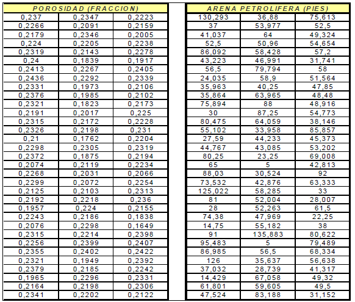

El ejercicio se realizará por etapas.

Etapa 1 - Aplicación de la estadistica descriptiva

1. Elaborar un histograma de frecuencias de la variable random “porosidad del yacimiento”
2. Elaborar un histograma acumulado directo de la variable random “porosidad del yacimiento”
3. Calcular las medidas de la tendencia central de la variable (media, mediana y moda)
4. Calcular las medidas de dispersión de la variable (desviación estándar y varianza)

*Etapa 1 - Distribuciones Empíricas o Histogramas*

El primer paso en el examen de un conjunto de datos, tomados como muestra representativa de una variable aleatoria, es agruparlos en forma tal que puedan apreciarse inmediatamente sus particularidades, en especial la forma en que están distribuidos los mismos, el grado de dispersión, y los valores con más alta probabilidad de ocurrencia.

El método más sencillo para lograr estas observaciones es crear un histograma de Frecuencias Relativas, para lo cual deben seguirse los siguientes pasos:

1. Determinar el recorrido o amplitud de la población o muestra, restando el valor máximo obtenido del mínimo.
2. Dividir el recorrido en un número de rangos o clases, seleccionados convenientemente de forma de no desvirtuar el dominio de la variable aleatoria. Una forma de estimar el ancho de clase es la Regla de Sturges que establece que el número de clases viene dado por:

   k=√n

   Donde:

   k = número de clases n = tamaño de muestra
3. Contar el número de observaciones que corresponden a cada rango o clase
4. Calcular la frecuencia relativa para cada rango o clase con la siguiente formula: Frecuencia Clasei = Nº observaciones en Rango o Clasei / Nº total observaciones
5. Construir el gráfico resultante

Antes de iniciar con el proceso de manipulacion de la data en python debemos importar las librerias correspondientes e importar la data a un matrix donde podamos realizar las acciones correspondientes en cada uno de los datos

```python
"""Para manipular y visualizar la data, se ha preparado previamente un archivo en formato cvs dejando 2 columnas: Porosidad
y Areana. El archivo inicialmente se prepara en excel y se exporta al formato csv. Con el editor de texto se cambian las
comas decimales por puntos y los punto y comas de separacion de los datos por comas ya que es el formato estandar a usar para
manipular la data en Python"""

# Primeramente importamos las bibliotecas mas importantes para esta etapa que son:
"""
Pandas - es una biblioteca de código abierto con licencia BSD que proporciona estructuras de datos y herramientas de
análisis de datos de alto rendimiento y fáciles de usar para el lenguaje de programación Python.

Matplotlib - es una biblioteca de trazado 2D de Python que produce cifras de calidad de publicación en una variedad
de formatos impresos y entornos interactivos en todas las plataformas. Matplotlib se puede usar en scripts de Python, los shells
de Python e IPython, el cuaderno Jupyter, los servidores de aplicaciones web y cuatro kits de herramientas de interfaz gráfica
de usuario.

numpy - NumPy es el paquete fundamental para la computación científica con Python.

math - Este módulo proporciona acceso a las funciones matemáticas definidas por el estándar C.
"""

import pandas as pd
import numpy as np
import matplotlib
import matplotlib.pyplot as plt
import math as mth
```

```python
"""Importamos la data a una variable llamada DATA, y visualizamos su primeras 10 lineas para observar que el archivo se
importó correctamente y no tenemos problemas con las variables"""

DATA = pd.read_csv("DATOS YACIMIENTOS.csv")
DATA.head(10)
```

|  | POROSIDAD | ARENA |
| --- | --- | --- |
| 0 | 0.2370 | 130.293 |
| 1 | 0.2266 | 37.000 |
| 2 | 0.2179 | 41.037 |
| 3 | 0.2240 | 52.500 |
| 4 | 0.2319 | 86.092 |
| 5 | 0.2400 | 43.223 |
| 6 | 0.2413 | 56.500 |
| 7 | 0.2436 | 24.035 |
| 8 | 0.2331 | 35.963 |
| 9 | 0.2376 | 35.864 |

```python
#Aislamos la data en una variable porosidad y una para arena definimos el total de elementos de la serie
porosidad = DATA["POROSIDAD"]
arena = DATA["ARENA"]
```

**1. Histrograma de frecuencia**

El histograma de frecuencias nos permite contestar preguntas como:

¿Cuál es la probabilidad de que X tome un determinado valor xi? ¿Cuál es el valor o el rango de valores de X con mayor probabilidad de ocurrencia? ¿De qué manera se distribuyen los probables valores de X?

```python
"""Primeramente calcularemos el parametro de clases para comparar con el resultado al construir el histrograma con los
parametros por defecto"""

# Contamos la cantidad de elementos de los datos de porosidad
cant_elemt = porosidad.count()
k = round(mth.sqrt(cant_elemt))
print("El numero correcto de clases es: " + str(k))
```

```
El numero correcto de clases es: 10
```

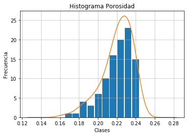

```python
# Llamamos la funcion hist de la biblioteca matplotlib.pyplot que importamos al inicio

# bins = auto para dejar que la libreria haga el calculo del numero de clases y podamos comparlo
# rwidth = 0.9 para que las barras del grafico queden separadas una de la otra
plt.hist(porosidad, bins="auto" , rwidth=0.9)
# plot.kde - kernel density equivalent realiza una grafica ajustada al comportamiento de los datos, por el momento no
# profundizaremos en este tema
porosidad.plot.kde(bw_method='silverman')
plt.title("Histograma Porosidad")
plt.xlabel('Clases')
plt.ylabel('Frecuencia')
# el parametro de aplpha = 0.75 se pone para visualizar una rejilla en la grafica
plt.grid(alpha=0.75)
```

**Histograma inicial**

Como podemos observar el histograma por sí solo no nos proporciona mayor información respecto a la distribución de los datos. La aplicación de esta librería retorna una información que podremos utilizar para el análisis de la información, pero debe ser extraída y manipulada manualmente. Pueden encontrar mayor información sobre la librería en la siguiente dirección: https://matplotlib.org/api/_as_gen/matplotlib.pyplot.hist.html#matplotlib.pyplot.hist

Para facilitar el análisis procederemos a crear una función que construya la misma grafica pero que exporte la información en forma de tabla con el fin de realizar el análisis de la distribución de los datos.

```python
# A continuacion se define una funcion para construir el histrograma de frecuencia, con el objetivo de exporta una tabla de
# resultados para su posterior analisis.

def histo_frec(data, nombre):
    #Definimos variables globales, esta variable sera el dataframe que contendra la tabla de resultados del histrograma
    global matrix_frame_frec
    # Definimos la cantidad de elementos
    cant_elemt = data.count()
    # Definimos el numero de clases
    k = round(mth.sqrt(cant_elemt))

    # Definimos parametros basicos del histograma, tanto por puntos como por densidad de poblacion
    n, bins = np.histogram(data, bins=k)
    m, bins2 = np.histogram(data, bins=k, density=True)

    # Creamos variable para almacenar las clases
    clases=[]
    # Creamos variable para almacenar la tabla de resultados
    matrix =[]
    #Calculamos la probabilida de ocurrencia de los eventos
    prob =n/cant_elemt
    # Construimos el array de clases
    for i in range(0,k):
        par_val=(round(bins[i],4),round(bins[i+1],4))
        clases.append(par_val)
    # Construmios la tabla de datos almacenandola en la matrix
    for i in range(0,k):
        diccionario ={"Clases":clases[i],"# Puntos":n[i],"Probabilidad":round(prob[i],4), "Densidad":m[i]}
        matrix.append(diccionario)
    matrix_frame_frec = pd.DataFrame(matrix)

    #Construimos el histograma
    plt.hist(data, bins=k , density = True, rwidth=0.9)
    data.plot.kde(bw_method='silverman')
    plt.title(nombre)
    plt.xlabel('Clases')
    plt.ylabel('Frecuencia')
    plt.grid(alpha=0.75)


    return plt.show(), matrix_frame_frec
```

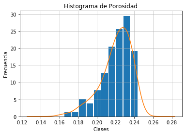

```
(None,              Clases  # Puntos  Probabilidad   Densidad
 0  (0.1649, 0.1728)         1        0.0101   1.283483
 1  (0.1728, 0.1806)         1        0.0101   1.283483
 2  (0.1806, 0.1885)         4        0.0404   5.133931
 3  (0.1885, 0.1964)         3        0.0303   3.850449
 4  (0.1964, 0.2042)         6        0.0606   7.700897
 5  (0.2042, 0.2121)        10        0.1010  12.834829
 6    (0.2121, 0.22)        16        0.1616  20.535726
 7    (0.22, 0.2279)        20        0.2020  25.669657
 8  (0.2279, 0.2357)        23        0.2323  29.520106
 9  (0.2357, 0.2436)        15        0.1515  19.252243)
```

```python
# Ejecutamos la funcion histo_frec y le pasamos la data porosidad y el nombre que le pondremos a la grafica.
histo_frec(porosidad, "Histograma de Porosidad")
```

*Analisis del histrograma de frecuencias*

**2. Histograma de frecuencia acumulado**

En ocasiones estamos interesados en contestar preguntas como:

¿Cuál es la probabilidad de que X tome un valor menor o igual a determinado valor?

Para contestar esta pregunta es conveniente organizar gráficamente la información en la forma de un Histograma Acumulado Directo. De igual manera para facilitar el análisis de la información crearemos una función que grafique el histograma acumulado y nos entregue la información en forma de tabla para su posterior análisis.

```python
# A continuacion se define una funcion para construir el histrograma acumulado, con el objetivo de exporta una tabla de
# resultados para su posterior analisis.

def histo_cum(data, nombre):
    #Definimos variables globales, esta variable sera el dataframe que contendra la tabla de resultados del histrograma
    global hmatrix_frame_cum
    # Definimos la cantidad de elementos
    cant_elemt = data.count()
    # Definimos el numero de clases
    k = round(mth.sqrt(cant_elemt))
    # Definimos parametros basicos del histograma, tanto por puntos como por densidad de poblacion
    n, bins = np.histogram(data, bins=k)
    a =plt.hist(data, bins="auto" , density = True, cumulative= True, rwidth=0.9)
    cum =a[0]
    # Creamos variable para almacenar las clases
    clases=[]
    # Creamos variable para almacenar la tabla de resultados
    matrix =[]
    # Construimos el array de clases
    for i in range(0,k):
        par_val=(round(bins[i],4),round(bins[i+1],4))
        clases.append(par_val)
    for i in range(0,k):
        diccionario ={"Clases":clases[i],"# Puntos":n[i],"Probabilidad":cum[i]}
        matrix.append(diccionario)
    matrix_frame_cum = pd.DataFrame(matrix)

    #Construimos el histograma
    plt.title(nombre)
    plt.xlabel('Clases')
    plt.ylabel('Frecuencia')
    plt.grid(alpha=0.75)

    return plt.show(), matrix_frame_cum
```

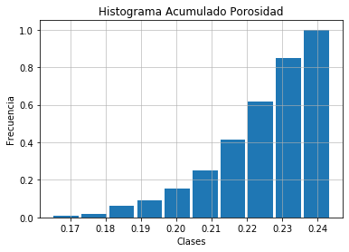

```
(None,              Clases  # Puntos  Probabilidad
 0  (0.1649, 0.1728)         1      0.010101
 1  (0.1728, 0.1806)         1      0.020202
 2  (0.1806, 0.1885)         4      0.060606
 3  (0.1885, 0.1964)         3      0.090909
 4  (0.1964, 0.2042)         6      0.151515
 5  (0.2042, 0.2121)        10      0.252525
 6    (0.2121, 0.22)        16      0.414141
 7    (0.22, 0.2279)        20      0.616162
 8  (0.2279, 0.2357)        23      0.848485
 9  (0.2357, 0.2436)        15      1.000000)
```

```python
histo_cum(porosidad,"Histograma Acumulado Porosidad")
```

*Analisis del histrograma de frecuencias acumuladas*

**2. Distribuciones de Probabilidad – Variables Continuas**

La mayoría de las Funciones de Probabilidad, Distribuciones de Densidad o Funciones de Densidad de Probabilidades “f(x)” se distinguen por su tradicional forma de campana. En todo caso, este tipo de representación matemática relaciona cualquier valor xi que pueda tomar la variable aleatoria continua “X”, con su probabilidad de ocurrencia f(xi).

f(xi)=p(X= xi)

La expresión anterior define la probabilidad de que la variable aleatoria tome un valor particular dentro de su dominio, lo cual es tan poco probable que para fines prácticos de le asigna una probabilidad cero. Esto es el caso de estar evaluando la altura física de una población determinada (Ejemplo Población de Bogotá) y evaluar la probabilidad de que ésta variable tome el valor especifico de 1,435 metros.

Bajo estas condiciones tiene mayor sentido práctico evaluar la probabilidad de que la variable aleatoria “X” tome valores comprendidos dentro de un rango. Esto aplicado al ejemplo mencionado en el párrafo anterior se traduce a estimar la probabilidad de que existan personas cuya altura física ente comprendida entre 1.4 y 1.5 metros.

Estas funciones permiten obtener información muy importante sobre la variable aleatoria. Los aspectos más importantes que pueden deducirse de este tipo de distribución son:

1. El dominio de la variable aleatoria.
2. El valor más probable de la variable aleatoria, que se ubicara debajo del punto más alto de la curva.
3. El grado de dispersión de la variable.

Algunas de las distribuciones de probabilidad paramétricas más usadas para variables continuas son las siguientes:

- Distribución Normal
- Distribución Lognormal
- Distribución Exponencial
- Distribución Weibull
- Distribución Beta
- Distribución Gamma
- Distribución Triangular
- Distribución Uniforme

**2.1 Principales Características de una Distribución de Probabilidad**

Una distribución se caracteriza, en general, por medio de tres criterios:

1. El valor central o medida de posición (la media, la mediana o la moda).
2. Una cantidad que expresa el grado de dispersión (la desviación estándar).
3. La forma de la curva, es decir, la forma general de la distribución probabilística.

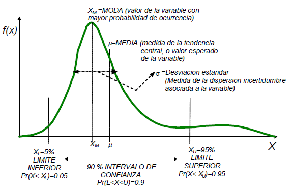

**2.2 Medidas de Posición o Tendencia Central (Media, Mediana y Moda)**

**2.2.1 Media**

La media o valor esperado es una idea fundamental en el estudio de las distribuciones de probabilidad que expresa básicamente la tendencia central o posición de la distribución. Como se muestra en la figura anterior, la media no es necesariamente el valor de mayor probabilidad de ocurrencia (como suele interpretarse de manera errónea); la media es “el centro de gravedad” de una distribución. Adicional a “esperanza matemática” o “valor esperado”, otros nombres comúnmente usados para referirse a la media son “average”, “promedio” y “centro de gravedad”

Esta figura ilustra la media de una muestra con cinco puntos de datos:

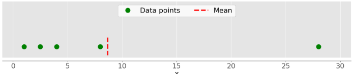

Los puntos verdes representan los puntos de datos 1, 2.5, 4, 8 y 28. La línea discontinua roja es su media, o (1 + 2.5 + 4 + 8 + 28) / 5 = 8.7.

```python
"""Para realizar el cálculo de la media en Python podemos realizarlo de varias formas, sin embargo, la data que importamos
se hizo a través de la biblioteca Pandas por lo cual nos centraremos en el análisis de la información con dicha herramienta"""

# Procedemos a calculas la media de las datas por separado de "Porosidad" y "Arena" que extrajimos de la DATA principal
media_poro= porosidad.mean()
media_poro
```

```
0.22047878787878786
```

*Análisis del resultado*

El valor promedio obtenido de porosida se ubica en el intervalo No 7 donde la probabilidad de ocurrencia es del 20%. Sin embargo los valores de mayor probabilidad se encuentran en el intervalo No 8 donde la probabilidad de ocurrencia es un poco mayor.

**2.2.2 Mediana**

La Mediana, es otra de las medidas o valores indicativos de la tendencia central de una distribución. Formalmente se define a la “Mediana” como el valor “x50%” que tiene una probabilidad acumulada de 50%; en otras palabras, la mediana es un valor de la variable aleatoria tal que el 50% de los probables valores de “X” serán menores o iguales de dicho valor y el otro 50% serán mayores.

El conjunto de datos se puede ordenar en orden creciente o decreciente. Si el número de elementos 𝑛 del conjunto de datos es impar, entonces la mediana es el valor en la posición media: 0.5 (𝑛 + 1). Si 𝑛 es par, entonces la mediana es la media aritmética de los dos valores en el medio, es decir, los elementos en las posiciones 0.5𝑛 y 0.5𝑛 + 1.

Por ejemplo, si tiene los puntos de datos 2, 4, 1, 8 y 9, entonces el valor medio es 4, que se encuentra en el medio del conjunto de datos ordenados (1, 2, 4, 8, 9). Si los puntos de datos son 2, 4, 1 y 8, entonces la mediana es 3, que es el promedio de los dos elementos intermedios de la secuencia ordenada (2 y 4). La siguiente figura ilustra esto:

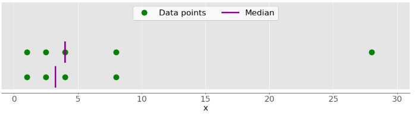

La principal diferencia entre el comportamiento de la media y la mediana está relacionada con los valores atípicos o extremos del conjunto de datos. La media se ve muy afectada por los valores atípicos, pero la mediana solo depende de los valores atípicos, ya sea ligeramente o nada. Considere la siguiente figura:

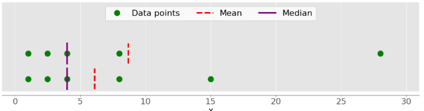

Si aumenta su valor (muévalo hacia la derecha), entonces la media aumentará, pero el valor medio nunca cambiará. Si disminuye su valor (muévalo hacia la izquierda), la media disminuirá, pero la mediana seguirá siendo la misma hasta que el valor del punto de movimiento sea mayor o igual a 4.

Puede comparar la media y la mediana como una forma de detectar valores atípicos y asimetría en sus datos. Si el valor medio o el valor medio es más útil para usted depende del contexto de su problema particular.

Aquí hay una de las muchas posibles implementaciones de Python de la mediana:

```python
# Procedemos a calculas la mediana de las datas por separado de "Porosidad" y "Areana" que extrajimos de la DATA principal
median_poro= porosidad.median()
median_poro
```

```
0.2238
```

*Análisis del resultado*

El valor de la mediana es de 0.2238, siendo levemente mayor al promedio obtenido anteriormente de 0.2204 ubicándose en el mismo grupo No 7 de datos con la misma probabilidad de ocurrencia. Una diferencia tan pequeña entre estos dos parámetros, como veremos más adelante significa que los datos tienen una varianza muy pequeña, su desviación estándar será de poca incertidumbre y el ancho de los datos pequeños por lo que se puede confiar en la veracidad de los mismos ya que todos se relacionan directamente al proceso físico que estamos analizando sin que hubieran fallas en el método de detección que pudieran alterar los datos.

**2.2.3 Moda** La Moda, es también una medida que indica la tendencia central de una distribución. Formalmente se define como el valor xm de la variable aleatoria X, que tiene la mayor probabilidad de ocurrencia. Enla figura de introduccion del punto 2 se puede observar la representacion grafica del valor de la moda. Si no hay un solo valor, el conjunto es multimodal ya que tiene múltiples valores modales. Por ejemplo, en el conjunto que contiene los puntos 2, 3, 2, 8 y 12, el número 2 es el modo porque ocurre dos veces, a diferencia de los otros elementos que ocurren solo una vez.

```python
moda_poro= porosidad.mode()
moda_poro

# Como puede ver, .mode () devuelve un nuevo pd.Series que contiene todos los valores modales.
```

```
0    0.2198
1    0.2240
2    0.2298
3    0.2315
4    0.2319
5    0.2321
6    0.2331
dtype: float64
```

*Análisis del resultado* En cuanto a la moda, el software nos devuelve un listado de 7 diferentes puntos donde se encontraron la mayor cantidad de coincidencias. De los 7 datos, 6 se encuentran en los intervalos de mayor probabilidad de ocurrencia y al no tener un solo parametro de media nos corrobora que estamos analizando un proceso natural totalmente aleatorio, pero que nos permitira, en este caso, caracterizar la porosidad esperada del yacimiento evaluado. Como veremos mas adelante al verificar los datos completos, existe una correlacion estre la porosidad y el nivel de arena esperado que nos permitira comparar este yacimiento con muchos otros para determinar el potencial del mismo.

**2.3 Medidas de Dispersión**

La dispersión de una distribución de probabilidad puede considerarse la característica más importante de la misma ya que en ella esta retratada la información sobre la incertidumbre de la variable random en estudio. En otras palabras, la dispersión es un indicativo de la incertidumbre relacionada con la variable; por ello, al cuantificar la dispersión estamos cuantificando el nivel de incertidumbre de la variable en análisis.

Las decisiones que se toman en relación con variables random serán más difíciles, en la medida en que las variables tengan un mayor grado de dispersión, y viceversa, serán más fáciles en la medida en que las variables sean menos dispersas.

En esta sección, aprenderá a identificar y calcular las siguientes medidas de dispercion:

- Varianza
- Desviación Estándar
- Coeficiente de Variación
- Asimetria estadistica
- Percentiles
- Rangos

**2.3.1 Varianza**

La varianza de la muestra cuantifica la propagación de los datos. Muestra numéricamente cuán lejos están los puntos de datos de la media. Puede expresar la varianza muestral del conjunto de datos 𝑥 con 𝑛 elementos matemáticamente como 𝑠² = Σᵢ (𝑥ᵢ - mean (𝑥)) ² / (𝑛 - 1), donde 𝑖 = 1, 2, ..., 𝑛 y media (𝑥) es la media muestral de 𝑥. Si desea comprender más profundamente por qué divide la suma con 𝑛 - 1 en lugar de 𝑛, puede profundizar en https://en.wikipedia.org/wiki/Bessel%27s_correction

La siguiente figura muestra por qué es importante considerar la variación al describir los conjuntos de datos:

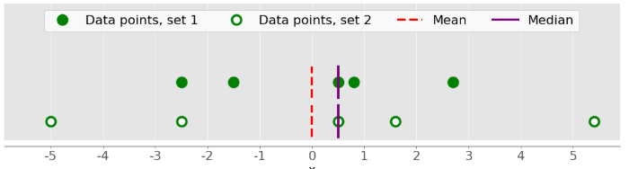

Hay dos conjuntos de datos en esta figura:

- Puntos verdes: este conjunto de datos tiene una varianza menor o una diferencia promedio menor de la media. También tiene un rango más pequeño o una diferencia más pequeña entre el dato más grande y el más pequeño.
- Puntos blancos: este conjunto de datos tiene una varianza mayor o una diferencia promedio mayor de la media. También tiene un rango mayor o una diferencia mayor entre el dato más grande y el más pequeño.

Tenga en cuenta que estos dos conjuntos de datos tienen la misma media y mediana, a pesar de que parecen diferir significativamente. Ni la media ni la mediana pueden describir esta diferencia. Por eso necesita las medidas de variabilidad.

A continuación, le mostramos cómo puede calcular la varianza de la muestra con Python y su libreria Pandas:

```python
"""Calcula la varianza de la población de manera similar a la varianza de la muestra. Sin embargo, debe usar 𝑛 en el denominador
en lugar de 𝑛 - 1: Σᵢ (𝑥ᵢ - mean (𝑥)) ² / 𝑛. En este caso, 𝑛 es el número de elementos en toda la población. para realizar esto
en Pandas utilizamos el parametro ddof=0"""
var_muestra = porosidad.var()
var_poblacion = porosidad.var(ddof=0)
var_muestra,var_poblacion
```

```
(0.0002606439332096475, 0.00025801116620752983)
```

*Análisis de los resultados*

Independiente del resultado, entre menor es el valor de la varianza, menor es la dispersión que hay entre los datos. Para el caso de estudio, el resultado indica que los datos están muy concentrados tal y como se encontró en el histograma, donde el 60% de los datos se concentra en los intervalos 6, 7, 8, lo cual a su vez permite caracterizar el yacimiento según su porosidad.

**2.3.2 Desviación Estándar**

La medida de dispersión más útil es la desviación estándar ( σ ), la cual se corresponde a la raíz cuadrada de varianza (Var(x)).

Var(x)= σ2

En la figura se muestra que la amplitud o rango de una distribución puede ser cuantificado en términos de la desviación estándar. Una desviación estándar "σ" para cada lado de la media (es decir dos "σ" ) abarca el 68% de los probables valores de una variable random. El 90% de los probables valores de una variable random estarán dentro del rango que tiene 1.645 σ para cada lado de la media.

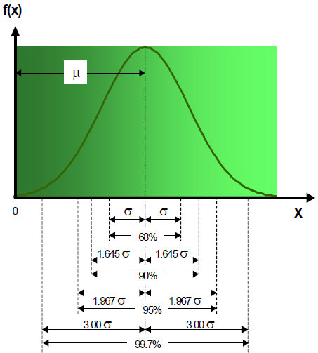

La desviación estándar a menudo es más conveniente que la varianza porque tiene la misma unidad que los puntos de datos. Una vez que obtenga la varianza, puede calcular la desviación estándar con Python y Pandas de la siguiente manera:

```python
stand_dev= porosidad.std()
stand_dev
```

```
0.016144470669850017
```

**Análisis del resultado**

Al igual que con la varianza, entre menor sea el resulado menor la dispersion de los datos. Considere +-10% del valor de la mediana encontrada con anterioridad, que nos daria el intervalo de 0.2014 - 0,2462 micras. Sumando el resultado de la desviacion estandar a la mediana encontramos un valor de 0,2398 micras lo cual nos indica que el valor de la desviacion estandar del set de datos analizados, en general, es levemente menor al 10%.

**2.3.3 Coeficiente de Variación**

El Coeficiente de Variación, es una medida de dispersión alternativa, de uso común, que se define como un cociente donde el numerador es la desviación estándar y el denominador es la media. Éste es una medida de dispersión de la distribución relativa a la media.

```python
coef_var= stand_dev/media_poro *100
coef_var
```

```
7.322459827167467
```

**Análisis del resultado**

Al igual que la desviación estándar el coeficiente de variación indica un % de variabilidad entre los datos. Para el caso en particular la variación entre los datos es del 7.32%; al compararlo con la desviación estándar obtenemos que son datos muy similares, por ende, es una medida para corroborar la desviación estándar. El cálculo de este parámetro no está incluido en ninguna de las librerías de Python, no obstante al ser tan sencillo de calcular se hace de manera manual.

**2.3.4 Asimetría estadistica**

La asimetría estadistica de la muestra mide la asimetría con relacion a un punto cero de una muestra de datos. El valor de la asimetria es positivo o negativo, dependiendo de a donde se inclinen los datos respecto al punto cero o la mediana.

Hay varias definiciones matemáticas de asimetría. Una expresión común para calcular la asimetría del conjunto de datos 𝑥 con 𝑛 elementos es (𝑛² / ((𝑛 - 1) (𝑛 - 2))) (Σᵢ (𝑥ᵢ - mean (𝑥)) ³ / (𝑛𝑠³)).

Una expresión más simple es Σᵢ (𝑥ᵢ - media (𝑥)) ³ 𝑛 / ((𝑛 - 1) (𝑛 - 2) 𝑠³), donde 𝑖 = 1, 2, ..., 𝑛 y media (𝑥) es la media muestral de 𝑥. La asimetría definida de esta manera se denomina al coeficiente de momento estandarizado de Fisher-Pearson ajustado.

La figura anterior mostró dos conjuntos de datos que eran bastante simétricos. En otras palabras, sus puntos tenían distancias similares a la media. En contraste, la siguiente imagen ilustra dos conjuntos asimétricos:

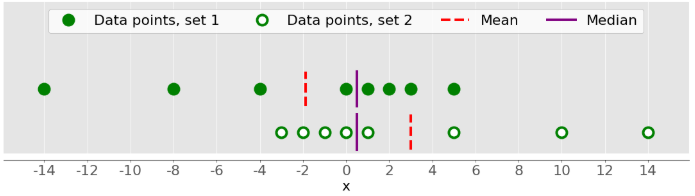

El primer conjunto está representado por los puntos verdes y el segundo con los blancos. Por lo general, los valores de asimetría negativa indican que hay una cola dominante en el lado izquierdo, que se puede ver con el primer conjunto. Los valores de asimetría positiva corresponden a una cola más larga o más gruesa en el lado derecho, que se puede ver en el segundo conjunto. Si la asimetría es cercana a 0 (por ejemplo, entre −0.5 y 0.5), el conjunto de datos se considera bastante simétrico.

```python
skew = porosidad.skew()
skew
```

```
-1.0695680366384361
```

**Analisis del resultado**

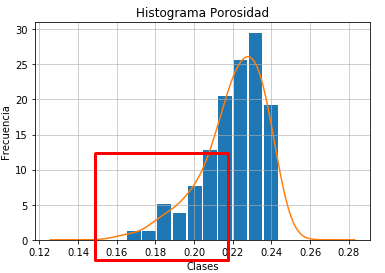

**2.3.5 Percentiles**

El 𝑝 percentil de muestra es el elemento en el conjunto de datos de tal manera que 𝑝% de los elementos en el conjunto de datos son menores o iguales a ese valor. Además, (100 - 𝑝)% de los elementos son mayores o iguales a ese valor. Si hay dos de estos elementos en el conjunto de datos, entonces el percentil de la muestra es su media aritmética. Cada conjunto de datos tiene tres cuartiles, que son los percentiles que dividen el conjunto de datos en cuatro partes:

- El primer cuartil es el percentil 25 de la muestra. Divide aproximadamente el 25% de los elementos más pequeños del resto del conjunto de datos.
- El segundo cuartil es el percentil 50 de la muestra o la mediana. Aproximadamente el 25% de los datoss se encuentran entre el primer y el segundo cuartil y otro 25% entre el segundo y el tercer cuartil.
- El tercer cuartil es el percentil 75 de la muestra. Divide aproximadamente el 25% de los datos más grandes del resto del conjunto de datos.

A continuacion revisaremos como realizar esta funcion en Python bajo la libreria Pandas:

```python
list_per = [0.25, 0.5, 0.75]
percentil = porosidad.quantile(list_per)
percentil
```

```
0.25    0.21205
0.50    0.22380
0.75    0.23200
Name: POROSIDAD, dtype: float64
```

**2.3.6 Intervalo de Confianza***

Cuando se hacen estimaciones o pronósticos de variables random, esta estimación básicamente consiste en *determinar la distribución de probabilidades* que representa a la variable de interés. En estos casos, nuestra estimación no debe expresarse como un solo valor estimado (para lo cual normalmente se utiliza el valor más probable o la media “ μ ” de la distribución); sino también la precisión de esa estimación.

Una forma conveniente de expresar la precisión consiste en especificar unos límites que, con una probabilidad dada, incluyan el valor verdadero de la variable. Dichos límites se denominan "límites de confianza", es decir, son límites que abarcan un intervalo dentro del cual podemos decir que se encuentra el valor verdadero con un cierto “grado de confianza”. Cuanto más distantes estén los límites entre sí, tanto mayor será la probabilidad de que incluyan el valor verdadero, pero más amplio será el rango de variación. El intervalo comprendido entre ambos límites se denomina intervalo de confianza.

En la siguiente figura, los valores “xa” y “xb” representan los límites de confianza; y la probabilidad “ α ” representa el grado de confianza o probabilidad de que el valor verdadero de la variable “X” se encuentre en el intervalo entre “xa” y “xb”.

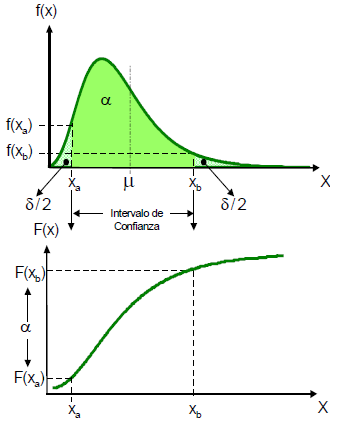

La probabilidad “α ” se denomina, también, coeficiente de confianza o nivel de confianza. Al decidir cuál es el nivel de confianza que se utilizará, se debe comprender que el objetivo principal del intervalo de confianza es comunicar el margen de error que puede tener nuestra estimación. Este margen de error se denota como “δ ” y se muestra en la figura representado por el área rayada. Un nivel de confianza del 95 % significa que se puede tener un error del 5 %.

α +δ = 1

Existen tres formas típicas para expresar una estimación sobre una variable random o aleatoria:

1. La Distribución Probabilística Completa.
2. Un rango de variación de la variable con su grado de certeza. Ejemplo: “X” varia entre “xa” y “xb” con (α=100) % de certeza).
3. Un estimado puntual (la media o la moda de la distribución). Ejemplo X=μ

Las formas “1” y “2” ofrecen información más fidedigna de la realidad.

```python
# En el momento no contamos con la distribución probabilística que se ajuste a nuestros datos, este análisis se realizara
# en la segunda etapa de análisis de los datos. Sin embargo, podemos realizar una deducción de un rango de variación a partir
# del histograma de frecuencias analizado al comienzo de este ejercicio para su análisis.

matrix_frame_frec
```

|  | Clases | # Puntos | Probabilidad | Densidad |
| --- | --- | --- | --- | --- |
| 0 | (0.1649, 0.1728) | 1 | 0.0101 | 1.283483 |
| 1 | (0.1728, 0.1806) | 1 | 0.0101 | 1.283483 |
| 2 | (0.1806, 0.1885) | 4 | 0.0404 | 5.133931 |
| 3 | (0.1885, 0.1964) | 3 | 0.0303 | 3.850449 |
| 4 | (0.1964, 0.2042) | 6 | 0.0606 | 7.700897 |
| 5 | (0.2042, 0.2121) | 10 | 0.1010 | 12.834829 |
| 6 | (0.2121, 0.22) | 16 | 0.1616 | 20.535726 |
| 7 | (0.22, 0.2279) | 20 | 0.2020 | 25.669657 |
| 8 | (0.2279, 0.2357) | 23 | 0.2323 | 29.520106 |
| 9 | (0.2357, 0.2436) | 15 | 0.1515 | 19.252243 |

**Análisis del resultado**

Para el presente set de datos podemos deducir que:

**El valor esperado X variará entre 0.2042 - 0.2436 micras con un nivel de confianza del 84% y un respectivo marjen de error del 16%.**

Aunque no es un dato muy acertado, esta evaluacion se ajusta a la distribucion de los datos en el histograma; para dar un dato mas preciso necesitamos hallar el modelo de distribucion que se ajusta a los datos, lo cual realizaremos en una segunda fase de aprendisaje.

**3. Resumen de estadísticas descriptivas**

A lo largo del presente articulo hemos visto como calcular individualmente los parametros estadisticos mas comunes al analizar un set de datos, sin embargo las librerias como Pandas y SciPy ofrecen rutinas útiles para obtener rápidamente estadísticas descriptivas con una sola función o llamada de método de la siguinte manera:

```python
porosidad.describe()
```

```
count    99.000000
mean      0.220479
std       0.016144
min       0.164900
25%       0.212050
50%       0.223800
75%       0.232000
max       0.243600
Name: POROSIDAD, dtype: float64
```

**4. Literatura utilizada**

Para la elaboración del presente documento se utilizaron muchas fuentes bibliográficas pero en especial las siguientes:

Libros:

- Confiabilidad Integral, un enfoque práctico, R2M S.A

  Artículos:
- Python Statistics Fundamentals: How to Describe Your Data - https://realpython.com/python-statistics/

  Documentación:
- Toda la documentación de las librerías de SciPy - https://www.scipy.org/docs.html

*Realizó:*

Javier A. Ochoa M.  
Director Confiabilidad  
3213192915  
director.confiabilidad@confipetrol.com  
ruslombia@gmail.com  
Cra 15 No 98 – 26 Oficina 401  
+(57 1) 423 29 49  
Bogotá – Colombia